# Clustering

Author

Bio Data Science^3

Published

# Preamble

## Goal

In this lab we will learn the basics of clustering. The methods we will cover include hierarchical clustering, K means and density clustering.

## Dependencies

```r
library(pheatmap)
library(ggfortify)
library(tidyverse)
```

## Data retrieval

The Morder data are gene expression measurements for 156 genes on T cells of 3 types (naïve, effector, memory) from 10 patients (Holmes et al. 2005).

Here we load the `Morder` `data.frame` from the online directory.

```r
load(url("http://web.stanford.edu/class/bios221/data/Morder.RData"))
# if download fails with timeout
# error, try increasing it via:
# options(timeout = 1000)
```

If you downloaded the file before, you can load it from the local directory.

```r
load("Morder.RData")
```

# Hierarchical clustering

**Question**

Inspect the data. How many samples of each T cell type (naïve, effector, memory) are there in the data?

In base R the function to perform hierarchical clustering is `hclust`. To cluster the genes with hierarchical clustering you first need to compute a distance matrix storing all pairwise (gene-to-gene) dissimilarities. This is how to do it:

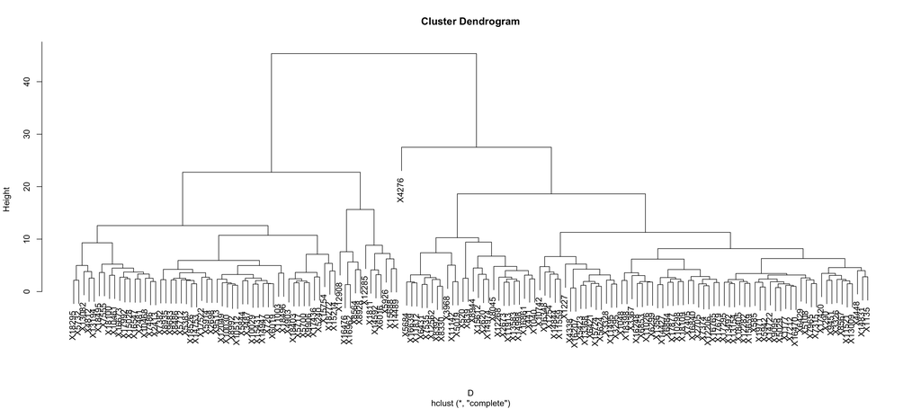

```r
# distance calculation
D = dist(t(Morder))
# clustering
gene_clust = hclust(d = D)
# plot dendrogram
plot(gene_clust)
```

**Question**

Why in the provided code the input to `dist` function is `t(Morder)`?

In hierarchical clustering, one needs to choose the method for agglomerating the clusters. By default `hclust`, uses a “complete” linkage method (see `?hclust` for info).

**Question**

Redo hierarchical clustering with the `ward.D2` method and plot the dendrogram.

Notice that the values on the y axis of hclust dendrogram changed. What do they correspond to?

Note that in the `hclust` there are the `ward.D` and `ward.D2` methods available. Please call `?hclust` to read about the difference between the two methods.

Next, instead of clustering genes, we will apply hierarchical clustering for samples (observations).

**Question**

Use dist and hclust (with default linkage method) to cluster samples.

How many clusters of samples are there at the dendrogram height of 12? Hint: the `abline()` and `cutree()` functions might be helpful.

Now that you know how to perform hierarchical clustering, use `pheatmap` to generate a heatmap with clustered rows and columns. Below, we do some extra work compared to the default parameters to make sure that 0 is in the center of the color scale, and use beautiful colors.

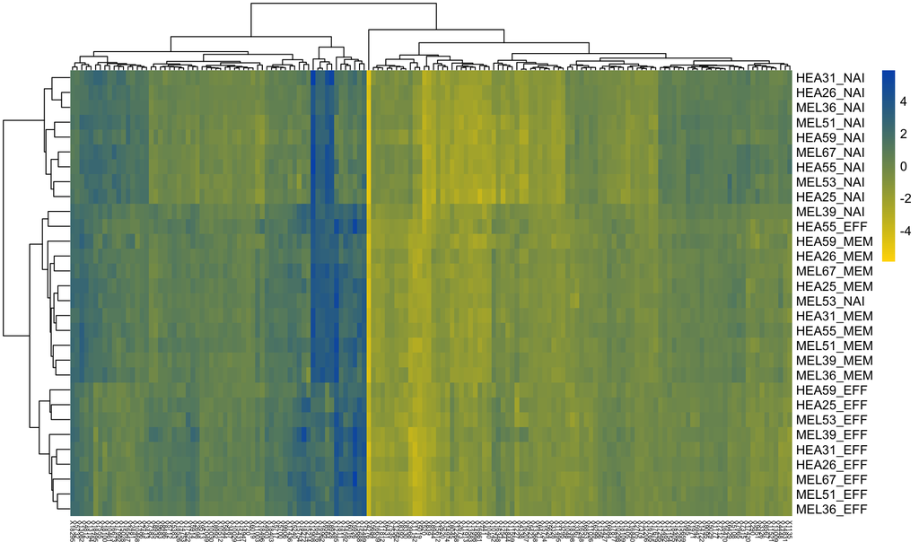

```r
library("pheatmap")
mycolors = colorRampPalette(c("#FFD800", "#0056B9"))(100)
pheatmap(
  mat = Morder,
  fontsize_col = 5, fontsize_row = 10,
  color = mycolors,
  breaks = max(abs(Morder)) * seq(-1, +1, length.out = length(mycolors) + 1)
)
```

**Question**

What type of distance and which clustering method does `pheatmap` use by default for clustering rows and columns?

Note that these are default values for `dist` and `hclust`, too. Look at how clustering heatmap changes if you use different distance and clustering methods (e.g. ‘ward.D2’).

# K means

Next we will do k-means clustering on the same dataset. First thing we need to do is select the number of clusters. In this dataset, we expect to have three clusters (naïve, effector, memory T cells). We will use the `kmeans` function to cluster the data into 3 groups.

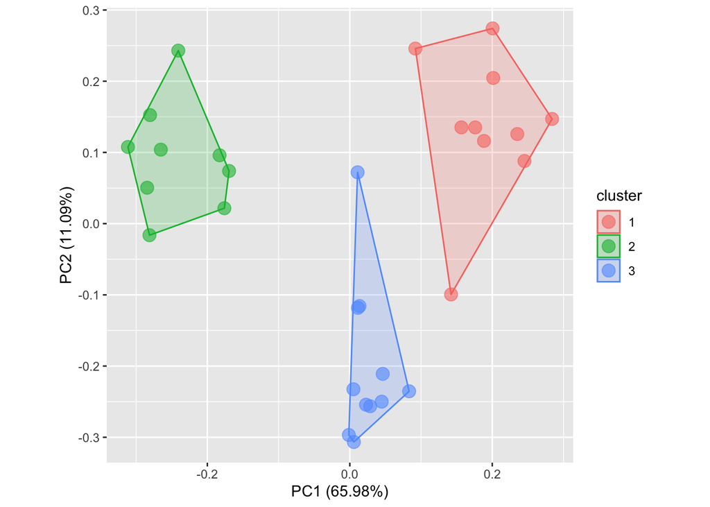

```r
# convert to data.frame
Morder_df <- as.data.frame(Morder)

# add cell type  column - wee will use this for plotting
Morder_df$cell_type <- stringr::str_extract(rownames(Morder), "EFF|MEM|NAI")
Morder_df$condition <- stringr::str_extract(rownames(Morder), "HEA|MEL")

# k means
set.seed(1234)
km <- kmeans(x = Morder[, -match(c("cell_type","condition"), colnames(Morder_df))], centers = 3)

# we can visualize the results
autoplot(km, Morder_df, frame = TRUE, size = 4, alpha = 0.6) + coord_equal()
```

**Question**

Check how different cell types are distributed in the three clusters, i.e. are the samples clustering by the cell types? Hint: use “shape” argument of the `autoplot` function to indicate cell types.

**Question**

Notice that one cluster contains samples from different cell types. If you repeat k means with k=4, do they separate?

**Question**

The data are coming from two conditions: healthy and melanoma. Repeat k-means clustering with k=2 and see if the clusters now correspond to these conditions?

Choosing the number of clusters for k-means is important and at the same time not trivial, because usually we don’t know the number of clusters in the data *a priori*.

How can we choose appropriate value of `k`?  
One way to choose the number of clusters is to use of the “wss” (within sum of squares) statistic.

`kmeans()` function reports wss for every cluster in the results (check `km$withinss`). Here we implement the function that computes the wss statistic for different number of clusters in kmeans.

```r
wssplot <- function(data, nc=10, seed=1234){
  wss <- (nrow(data)-1)*sum(apply(data,2,var))
  print(wss)
  for (i in 2:nc){
    set.seed(seed)
    wss[i] <- sum(kmeans(data, centers=i)$withinss)}
  plot(1:nc, wss, type="b", xlab="Number of Clusters",
       ylab="Within groups sum of squares")
  wss
}
```

Inspect how `wss` looks for different number of clusters in our `Morder` data.

```
[1] 1917.597
```

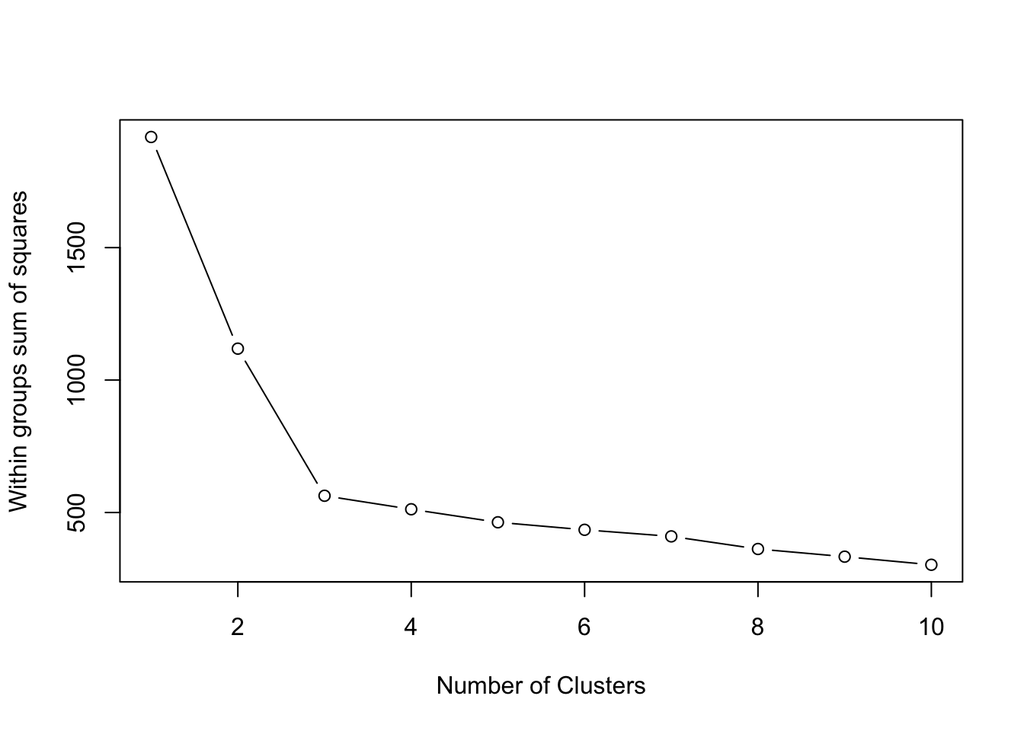

```
 [1] 1917.5966 1118.6389  563.2533  512.2840  463.1191  434.7435  409.9065
 [8]  362.2863  333.3141  302.7442
```

```r
wssplot(Morder)
```

Within sum of squares (wss) statistic, we see that the last substantial decrease of the statistic occurres before $k=3$, and for values $k=4,5,6,\dots$ the quantity ‘levels-off’. In practice, we would choose $k=3$, a value happening at the ‘elbow’ of the plot (elbow-rule).